# Student Sit In

Erika Amado

10/26/2019

# ONE SHOT assignment!

this is an extra credit assignment, must be completed Monday Oct 28, turn-in closes at midnight!

## Problem statement:

Students at UCD- is there a relation between where one sits and one’s major?

## Introduction

The data came from a observational study done at UC Davis. The variables that we are focused on are seat(front, back or middle) and major(liberal arts or non-liberal arts).

$H_0$: there is no relationship between one’s major and where one sits in a class  
$H_A$: where one sits in class and one’s major are related

names of the data in the data frame

```
##  [1] "seat"           "major"          "data.Sex"       "data.TV"
##  [5] "data.computer"  "data.Sleep"     "data.Seat"      "data.alcohol"
##  [9] "data.Height"    "data.momheight" "data.dadheight" "data.exercise"
## [13] "data.GPA"       "data.class"
```

## Methods

Both variables in this data are categorical. For the graph we will be using a bar chat. For the numerical we will be using a table. For the inferential we used a chi-squared test.

## Data summary

**Graphical summary**

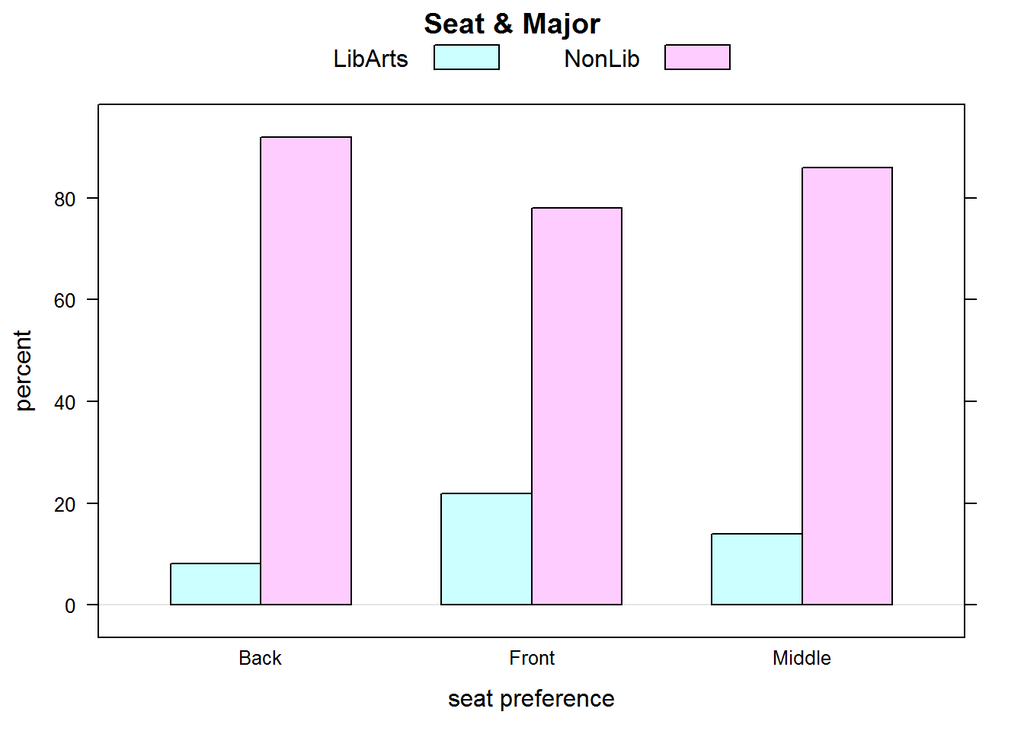

This graph displays seat preference for liberal and non-liberal art majors. Non-liberal art students seem to be more evevly spread out compared to liberal art students. More liberal art students tend to sit in the front row.

**Numerical summary**

```
##         major
## seat     LibArts NonLib  Total
##   Back      8.11  91.89 100.00
##   Front    21.95  78.05 100.00
##   Middle   13.98  86.02 100.00
```

This table displays how non-liberal arts majors are more evenly spread out. Liberal arts majors seat preference is higher for front seats and lowest for back seats.

## Inferential Results

```
## Pearson's Chi-squared test
##
## Observed Counts:
##         major
## seat     LibArts NonLib
##   Back         3     34
##   Front        9     32
##   Middle      13     80
##
## Counts Expected by Null:
##         major
## seat     LibArts NonLib
##   Back      5.41  31.59
##   Front     5.99  35.01
##   Middle   13.60  79.40
##
## Contributions to the chi-square statistic:
##         major
## seat     LibArts NonLib
##   Back      1.07   0.18
##   Front     1.51   0.26
##   Middle    0.03   0.00
##
##
## Chi-Square Statistic = 3.053
## Degrees of Freedom of the table = 2
## P-Value = 0.2173
```

The p-value is 0.2173 > 0.05.

## Results and conclusions

The p-value is 0.2173 which is greater than 0.05 so we fail to rejct the null hypothesis and conclude we do not have evidence to support that certain majors tend to sit in particular areas of the class.